#### 12.03.24, © [Evhenii Kostin](https://www.linkedin.com/in/%D0%B5%D0%B2%D0%B3%D0%B5%D0%BD%D0%B8%D0%B9-%D0%BA%D0%BE%D1%81%D1%82%D0%B8%D0%BD-8287b0264/), 2024

# Лабораторна робота №8. Побудова дерев ухвалення рішень

**Мета:** *закріпити на практиці концепцію алгоритмів побудови дерев ухвалення рішень засобами мови Python.*

# Завдання для самостійної роботи

1. Реалізувати алгоритм побудови класифікаційного дерева ухвалення рішень, наведений в роботі, для свого варіанта, обгрунтувавши знаення відповідних параметрів.

## Побудова дерева ухвалення рішень мовою python

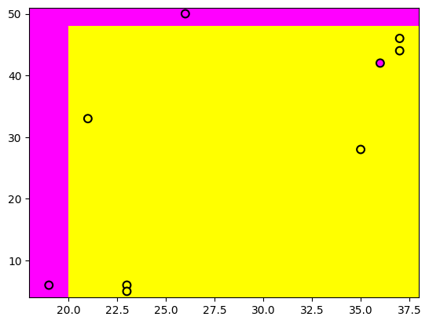

[output not shown]

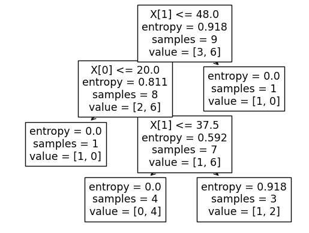

```python
import numpy as np
import matplotlib.pyplot as plt
from sklearn.tree import DecisionTreeClassifier, plot_tree

# Функція для створення сітки
def get_grid(data):
    x_min, x_max = data[:, 0].min() - 1, data[:, 0].max() + 1
    y_min, y_max = data[:, 1].min() - 1, data[:, 1].max() + 1
    return np.meshgrid(np.arange(x_min, x_max, 0.01), np.arange(y_min, y_max, 0.01))

# Ваші дані
x_train_9 = np.array([[37, 46], [26, 50], [23, 6], [21, 33], [36, 42], [37, 44], [19, 6], [23, 5], [35, 28]])
y_train_9 = np.array([1, -1, 1, 1, -1, 1, -1, 1, 1])

# Ініціалізація та навчання моделі дерева ухвалення рішень
clf_tree = DecisionTreeClassifier(criterion='entropy', max_depth=3, random_state=5)
clf_tree.fit(x_train_9, y_train_9)

# Отримання прогнозів та відображення сітки та точок даних
xx, yy = get_grid(x_train_9)
predicted = clf_tree.predict(np.c_[xx.ravel(), yy.ravel()]).reshape(xx.shape)
plt.pcolormesh(xx, yy, predicted, cmap='spring', shading='auto')
plt.scatter(x_train_9[:, 0], x_train_9[:, 1], c=y_train_9, s=50, cmap='spring', edgecolors='black', linewidth=1.5)
plt.show()

# Візуалізація дерева
plot_tree(clf_tree)
```

## Відповіді на контрольні запитання

#### 1.Особливості дискретного випадку в логічних методах класифікації:

*Дискретний випадок передбачає наявність обмеженого набору можливих значень для кожного атрибута або функції, що описують дані.* *Вхідні дані представлені у вигляді категорій або дискретних значень, які можуть бути легко ідентифіковані та порівняні між собою.* *Використовуються методи, які опираються на логічні правила, щоб класифікувати дані на основі наявних категорій.*

#### 2.Властивості неперервного випадку в логічних методах класифікації:

*Неперервний випадок передбачає наявність атрибутів або функцій, що приймають значення з континууму.* *Дані можуть бути відображені на вісі числових значень, і вони можуть приймати будь-які значення всередині певного діапазону.* *Використовуються методи, які зазвичай базуються на статистичних моделях або алгоритмах, що працюють з неперервними значеннями.*

#### 3.Критерії якості для побудови дерев ухвалення рішень:

*Ентропія: міра невизначеності в системі, використовується для вимірювання того, наскільки добре вузли дерева розділяють дані за допомогою атрибутів.* *Інформаційний приріст: вимірює, як добре певний атрибут розділяє дані на класи, порівнюючи ентропію перед і після розділення.* *Джині: міра чистоти чи гомогенності вузла дерева, використовується для визначення оптимального розділення даних.* *Помилка класифікації: вимірюється точність класифікації моделі на основі випадкового вибору.*

#### 4.Робота алгоритму ID3 у контексті побудови дерев класифікації:

*ID3 (Iterative Dichotomiser 3) є одним з перших алгоритмів для побудови дерев класифікації.* *Він працює на принципі жадібного підходу, рекурсивно розділяючи набір даних на більші частини шляхом вибору найбільш інформативного атрибута на кожному кроці.* *На кожному кроці алгоритм обирає атрибут, який найкраще розділяє набір даних, зазвичай за допомогою критерію інформаційного приросту або ентропії.* *Процес триває до тих пір, поки всі дані не будуть розділені на чисті класи або досягнута максимальна глибина дерева.* *Результатом є дерево рішень, яке може бути використане для класифікації нових даних за їхніми атрибутами.*

[figure not shown]

Created in Deepnote